# Pennsylvania State restaurants rating predictions using Natural Language Processing (NLP)

#### **Mapping**

```python
states = gpd.read_file('../data/RAW/GEOPANDAS_USA/gadm41_USA_1.shp')
states['ISO_1'] = states['ISO_1'].str.replace(r'US-', '')
states = states[~states['NAME_1'].isin(["Alaska", "Puerto Rico", "Hawaii"])].reset_index(drop=True)
```

```python
food_states = pd.merge(states, food, left_on='ISO_1', right_on='state', how='left')
gdf = gpd.GeoDataFrame(
    food_states, geometry=gpd.points_from_xy(food_states.longitude, food_states.latitude))
```

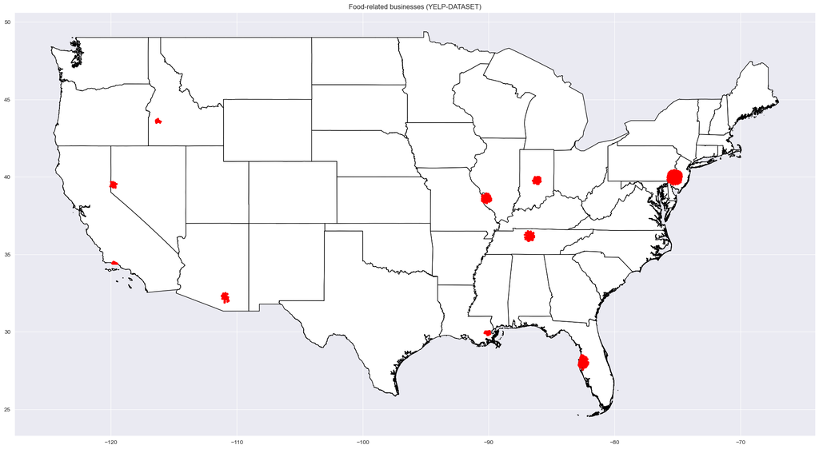

```python
base = states.plot(color='white', edgecolor='black',figsize=(25, 15))
gdf.plot(ax=base, marker='o', color='red', markersize=5)
base.set_title("Food-related businesses (YELP-DATASET)")
```

According to the map, It seems to be a bigger concentration of food-related businesess in **northeastern states**. We will look closer at it.

```python
states_filtered = states[states['NAME_1'].isin(["Connecticut", "Delaware", "District of Columbia", "Maine", "Maryland", "Massachusetts", "New Hampshire", "New Jersey", "New York", "Pennsylvania", "Rhode Island", "Vermont"])]
```

```python
food_states_filtered = pd.merge(states_filtered, food, left_on='ISO_1', right_on='state', how='left')
gdf = gpd.GeoDataFrame(
    food_states_filtered, geometry=gpd.points_from_xy(food_states_filtered.longitude, food_states_filtered.latitude))
```

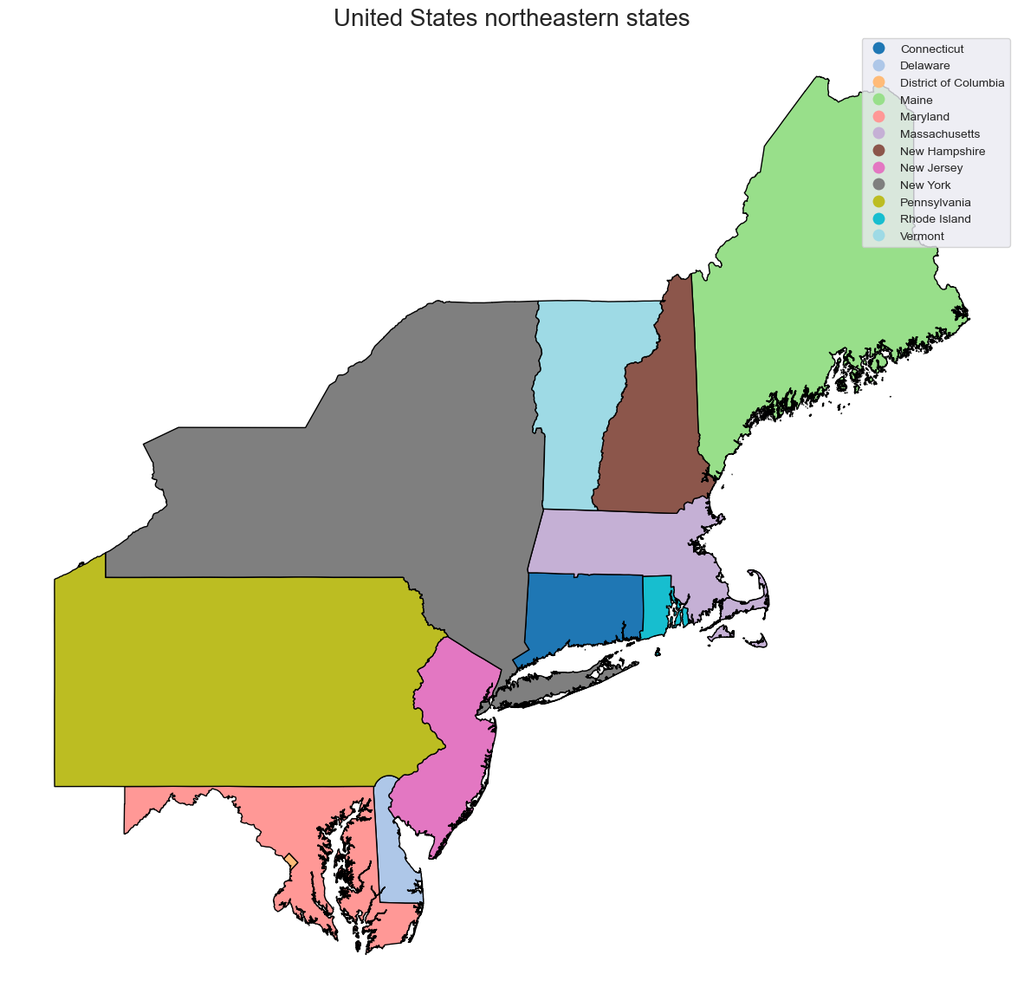

```python
fig, ax = plt.subplots(1, figsize = (15,15))
ax.set_title("United States northeastern states", fontdict={'fontsize': '20', 'fontweight' : '10'})
fig = states_filtered.plot(alpha=1, edgecolor='0', ax=ax, column='NAME_1', cmap='tab20',legend = True)
ax.axis('off')
plt.show()
```

```
State with more restaurants in the Dataset: PA - nº of restaurants: 10149
```

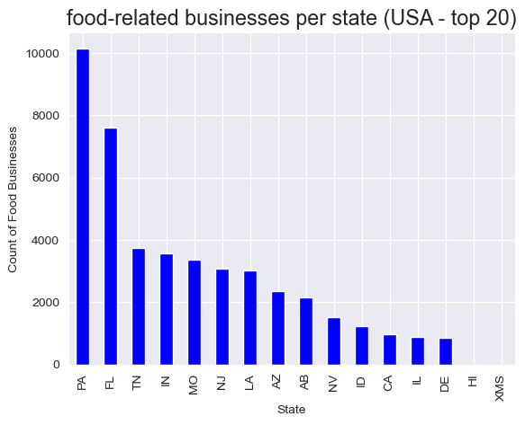

```python
food.state.value_counts(dropna=False)[0:20].plot(kind='bar',color='blue')
font = {'family' : 'sans-serif',
        'weight' : 'normal',
        'size'   : 14}
plt.rc('font', **font)
plt.title('food-related businesses per state (USA - top 20)')
plt.ylabel('Count of Food Businesses')
plt.xlabel('State')
plt.figure(figsize=(10,6))
sns.despine()
print('State with more restaurants in the Dataset:', food.state.value_counts(dropna=False)[0:20].idxmax(), '- nº of restaurants:', food.state.value_counts()[0])
```

Pennsylvania, an northeastern state, is the one with bigger amount of restaurants in the dataset, as we can see plotted in the following map.

```python
states_filtered = states[states['NAME_1'].isin(["Connecticut", "Delaware", "District of Columbia", "Maine", "Maryland", "Massachusetts", "New Hampshire", "New Jersey", "New York", "Pennsylvania", "Rhode Island", "Vermont"])]
```

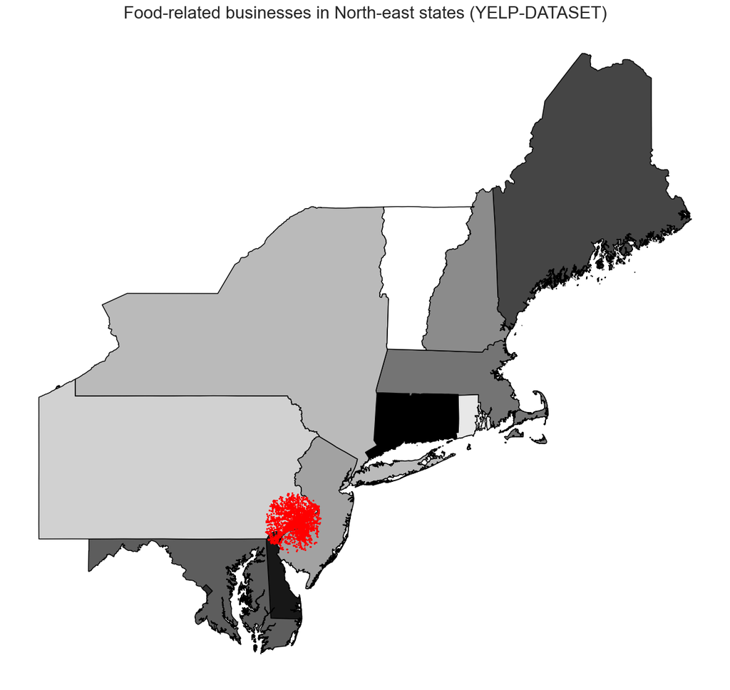

```python
fig, ax = plt.subplots(1, figsize = (15,15))
ax.set_title("Food-related businesses in North-east states (YELP-DATASET)", fontdict={'fontsize': '20', 'fontweight' : '10'})
fig = states_filtered.plot(alpha=1, edgecolor='0', ax=ax, column='NAME_1', cmap='gist_gray',legend = False)
gdf.plot(ax=ax, marker='*', color='red', markersize=1)
ax.axis('off')

plt.show()
```

as we can see, **Pennsylvania** is the state with the bigger amount of restaurants, so it may be chosen for our project.

```python
# We filter the restaurants located in Pennsylvania
foodpen = food[food['state'] == 'PA']
foodpen
```

|  | BusinessAcceptsCreditCards | RestaurantsDelivery | OutdoorSeating | RestaurantsPriceRange2 | RestaurantsTakeOut | ByAppointmentOnly | WiFi | Alcohol | Caters | WheelchairAccessible | ... | category1 | category2 | category3 | category4 | category5 | category6 | category7 | category8 | category9 | category10 |
| --- | --- | --- | --- | --- | --- | --- | --- | --- | --- | --- | --- | --- | --- | --- | --- | --- | --- | --- | --- | --- | --- |
| 3 | False | False | False | 1 | True | False | u'free' | u'none' | True | NaN | ... | Restaurants | Food | Bubble Tea | Coffee & Tea | Bakeries | None | None | None | None | None |
| 4 | True | NaN | NaN | NaN | True | NaN | NaN | NaN | False | True | ... | Brewpubs | Breweries | Food | None | None | None | None | None | None | None |
| 15 | True | True | True | 2 | True | NaN | 'free' | 'full_bar' | NaN | True | ... | Sushi Bars | Restaurants | Japanese | None | None | None | None | None | None | None |
| 19 | True | None | None | 1 | True | NaN | u'no' | u'none' | True | NaN | ... | Korean | Restaurants | None | None | None | None | None | None | None | None |
| 33 | True | True | False | 1 | True | NaN | u'no' | u'none' | True | NaN | ... | Pizza | Restaurants | None | None | None | None | None | None | None | None |
| ... | ... | ... | ... | ... | ... | ... | ... | ... | ... | ... | ... | ... | ... | ... | ... | ... | ... | ... | ... | ... | ... |
| 150269 | NaN | False | NaN | 2 | NaN | NaN | NaN | NaN | NaN | NaN | ... | Nightlife | Cafes | Hotels | Bars | Hotels & Travel | Restaurants | Event Planning & Services | None | None | None |
| 150297 | True | True | NaN | 2 | True | NaN | 'no' | NaN | NaN | NaN | ... | Convenience Stores | Sandwiches | Restaurants | Food | Grocery | None | None | None | None | None |
| 150306 | True | True | False | 2 | True | NaN | 'no' | u'none' | True | NaN | ... | Restaurants | Specialty Food | Food | Sandwiches | Italian | None | None | None | None | None |
| 150325 | True | True | NaN | 1 | True | NaN | NaN | NaN | True | NaN | ... | Restaurants | Sandwiches | Convenience Stores | Coffee & Tea | Food | None | None | None | None | None |
| 150336 | True | True | False | 2 | True | NaN | u'free' | u'none' | True | False | ... | Restaurants | Mexican | None | None | None | None | None | None | None | None |

10149 rows × 65 columns

```python
for i, col in enumerate(foodpen.columns):
    print(f"Column{i}: {col}")
```

```
Column0: BusinessAcceptsCreditCards
Column1: RestaurantsDelivery
Column2: OutdoorSeating
Column3: RestaurantsPriceRange2
Column4: RestaurantsTakeOut
Column5: ByAppointmentOnly
Column6: WiFi
Column7: Alcohol
Column8: Caters
Column9: WheelchairAccessible
Column10: GoodForKids
Column11: RestaurantsAttire
Column12: RestaurantsReservations
Column13: Ambience
Column14: CoatCheck
Column15: DogsAllowed
Column16: RestaurantsTableService
Column17: RestaurantsGoodForGroups
Column18: HasTV
Column19: HappyHour
Column20: DriveThru
Column21: GoodForMeal
Column22: NoiseLevel
Column23: BusinessAcceptsBitcoin
Column24: AcceptsInsurance
Column25: Smoking
Column26: Music
Column27: GoodForDancing
Column28: BestNights
Column29: BYOB
Column30: Corkage
Column31: BYOBCorkage
Column32: HairSpecializesIn
Column33: Open24Hours
Column34: RestaurantsCounterService
Column35: AgesAllowed
Column36: DietaryRestrictions
Column37: Monday
Column38: Tuesday
Column39: Wednesday
```

[output cut: 10 more lines]

```
Column50: latitude
Column51: longitude
Column52: stars
Column53: review_count
Column54: is_open
Column55: category1
Column56: category2
Column57: category3
Column58: category4
Column59: category5
Column60: category6
Column61: category7
Column62: category8
Column63: category9
Column64: category10
```

```python
foodpen.drop(foodpen.columns[[1,2,3,4,5,6,7,9,10,11,12,13,14,15,16,17,18,19,20,21,22,23,24,25,26,27,28,29,30,31,32,33,34,35,36,54,]], axis=1, inplace=True)
foodpen = foodpen.reset_index(drop=True)
foodpen.head(5)
```

|  | BusinessAcceptsCreditCards | Caters | Monday | Tuesday | Wednesday | Thursday | Friday | Saturday | Sunday | business_id | ... | category1 | category2 | category3 | category4 | category5 | category6 | category7 | category8 | category9 | category10 |
| --- | --- | --- | --- | --- | --- | --- | --- | --- | --- | --- | --- | --- | --- | --- | --- | --- | --- | --- | --- | --- | --- |
| 0 | False | True | 7:0-20:0 | 7:0-20:0 | 7:0-20:0 | 7:0-20:0 | 7:0-21:0 | 7:0-21:0 | 7:0-21:0 | MTSW4McQd7CbVtyjqoe9mw | ... | Restaurants | Food | Bubble Tea | Coffee & Tea | Bakeries | None | None | None | None | None |
| 1 | True | False | NaN | NaN | 14:0-22:0 | 16:0-22:0 | 12:0-22:0 | 12:0-22:0 | 12:0-18:0 | mWMc6_wTdE0EUBKIGXDVfA | ... | Brewpubs | Breweries | Food | None | None | None | None | None | None | None |
| 2 | True | NaN | NaN | 13:30-22:0 | 13:30-22:0 | 13:30-22:0 | 13:30-23:0 | 13:30-23:0 | 13:30-22:0 | MUTTqe8uqyMdBl186RmNeA | ... | Sushi Bars | Restaurants | Japanese | None | None | None | None | None | None | None |
| 3 | True | True | 11:30-20:30 | 11:30-20:30 | 11:30-20:30 | 11:30-20:30 | 11:30-20:30 | 11:30-20:30 | NaN | ROeacJQwBeh05Rqg7F6TCg | ... | Korean | Restaurants | None | None | None | None | None | None | None | None |
| 4 | True | True | 11:0-0:0 | 11:0-0:0 | 11:0-0:0 | 11:0-0:0 | 11:0-1:0 | 11:0-1:0 | 11:0-0:0 | kV_Q1oqis8Qli8dUoGpTyQ | ... | Pizza | Restaurants | None | None | None | None | None | None | None | None |

5 rows × 29 columns

#### Top Categories in Food-related businesess

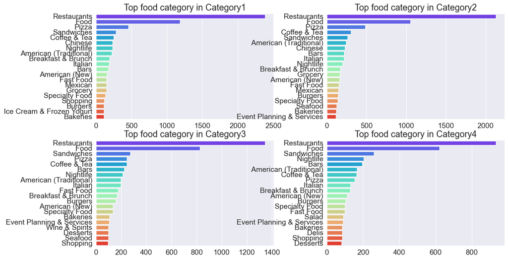

```python
f,ax = plt.subplots(2,2, figsize=(14,8))
ax1,ax2, ax3, ax4 = ax.flatten()
cnt = foodpen['category1'].value_counts()[:20].to_frame()

sns.barplot(x=cnt['category1'], y=cnt.index, palette='rainbow', ax=ax1)
ax1.set_xlabel('')
ax1.set_title('Top food category in Category1')

cnt = foodpen['category2'].value_counts()[:20].to_frame()

sns.barplot(x=cnt['category2'], y=cnt.index,  palette='rainbow', ax=ax2)
ax2.set_xlabel('')
ax2.set_title('Top food category in Category2')

cnt = foodpen['category3'].value_counts()[:20].to_frame()

sns.barplot(x=cnt['category3'], y=cnt.index, palette='rainbow', ax=ax3)
ax3.set_xlabel('')
ax3.set_title('Top food category in Category3')

cnt = foodpen['category4'].value_counts()[:20].to_frame()

sns.barplot(x=cnt['category4'], y=cnt.index,  palette='rainbow', ax=ax4)
ax4.set_xlabel('')
ax4.set_title('Top food category in Category4')
plt.subplots_adjust(wspace=0.3)
```

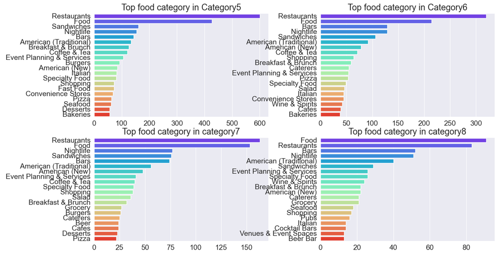

```python
f,ax = plt.subplots(2,2, figsize=(14,8))
ax1,ax2, ax3, ax4 = ax.flatten()
cnt = foodpen['category5'].value_counts()[:20].to_frame()

sns.barplot(x=cnt['category5'], y=cnt.index, palette='rainbow', ax=ax1)
ax1.set_xlabel('')
ax1.set_title('Top food category in Category5')

cnt = foodpen['category6'].value_counts()[:20].to_frame()

sns.barplot(x=cnt['category6'], y=cnt.index,  palette='rainbow', ax=ax2)
ax2.set_xlabel('')
ax2.set_title('Top food category in Category6')

cnt = foodpen['category7'].value_counts()[:20].to_frame()

sns.barplot(x=cnt['category7'], y=cnt.index, palette='rainbow', ax=ax3)
ax3.set_xlabel('')
ax3.set_title('Top food category in category7')

cnt = foodpen['category8'].value_counts()[:20].to_frame()

sns.barplot(x=cnt['category8'], y=cnt.index,  palette='rainbow', ax=ax4)
ax4.set_xlabel('')
ax4.set_title('Top food category in category8')
plt.subplots_adjust(wspace=0.3)
```

#### Average rating per city in Pennsylvania

```python
city_foodpen_reviews = foodpen[['city', 'review_count', 'stars']].groupby(['city']).agg({'review_count': 'sum', 'stars': 'mean'}).sort_values(by='review_count', ascending=False)
city_foodpen_reviews.head(50)
```

| city | review_count | stars |
| --- | --- | --- |
| Philadelphia | 530081 | 3.588262 |
| West Chester | 13942 | 3.615880 |
| King of Prussia | 13360 | 3.513889 |
| Media | 9563 | 3.673913 |
| Conshohocken | 8795 | 3.524096 |
| Wayne | 8499 | 3.688235 |
| Doylestown | 8161 | 3.680769 |
| New Hope | 7852 | 3.654321 |
| Bensalem | 7657 | 3.311258 |
| Newtown | 7019 | 3.695876 |
| Phoenixville | 7012 | 3.518018 |
| Ardmore | 6882 | 3.758824 |
| Exton | 6762 | 3.343750 |
| Malvern | 6610 | 3.797753 |
| North Wales | 6224 | 3.530488 |
| Lansdale | 5750 | 3.640909 |
| Willow Grove | 5680 | 3.256579 |
| Langhorne | 5442 | 3.315217 |
| Glen Mills | 5401 | 3.615385 |
| Norristown | 5345 | 3.577206 |
| Collegeville | 5109 | 3.664179 |
| Springfield | 4800 | 3.273256 |
| Yardley | 4756 | 3.601852 |
| King Of Prussia | 4646 | 2.987179 |
| Ambler | 4473 | 3.715517 |
| Downingtown | 4397 | 3.423611 |
| Bryn Mawr | 4364 | 3.567164 |
| Horsham | 4306 | 3.372727 |
| Kennett Square | 4234 | 3.756250 |
| Pottstown | 4220 | 3.375000 |
| Blue Bell | 4109 | 3.360000 |
| Plymouth Meeting | 4050 | 3.257143 |
| Havertown | 3755 | 3.576923 |
| Upper Darby | 3615 | 3.432099 |
| Jenkintown | 3563 | 3.520833 |
| Warminster | 3452 | 3.373494 |
| Levittown | 3430 | 3.321782 |
| Royersford | 3415 | 3.556338 |
| Warrington | 3403 | 3.353448 |
| Glenside | 3205 | 3.798246 |
| Newtown Square | 3184 | 3.650943 |
| Southampton | 2860 | 3.663043 |
| Bala Cynwyd | 2790 | 3.350000 |
| Drexel Hill | 2750 | 3.627119 |
| Elkins Park | 2613 | 3.819444 |
| Berwyn | 2570 | 3.772727 |
| Huntingdon Valley | 2367 | 3.564103 |
| Abington | 2364 | 3.453488 |
| Wynnewood | 2349 | 3.557692 |
| Bristol | 2295 | 3.622642 |

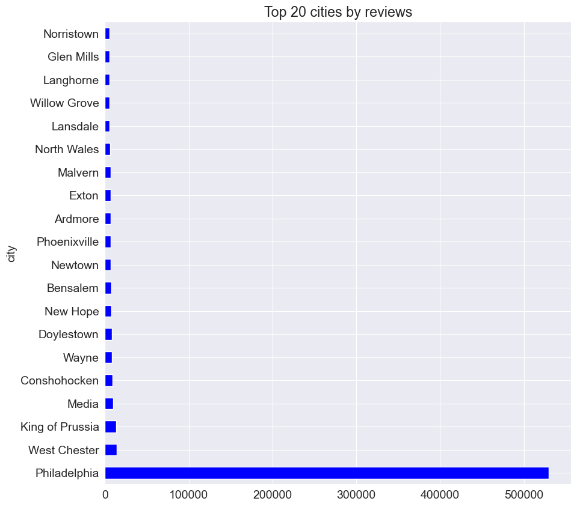

```python
city_foodpen_reviews['review_count'][0:20].plot(kind='barh', stacked=False, figsize=[10,10],colormap='winter')
plt.title('Top 20 cities by reviews')
```

#### **Saving the Dataset**

```python
foodpen['BusinessAcceptsCreditCards'] = foodpen.BusinessAcceptsCreditCards.astype(str).str.lower()
foodpen['Caters'] = foodpen.BusinessAcceptsCreditCards.astype(str).str.lower()
foodpen['address'] = foodpen.address.astype(str).str.lower()
foodpen['name'] = foodpen.name.astype(str).str.lower()
foodpen['BusinessAcceptsCreditCards'] = foodpen.BusinessAcceptsCreditCards.astype(str).str.lower()
foodpen['city'] = foodpen.city.astype(str).str.lower()
foodpen['state'] = foodpen.state.astype(str).str.lower()
foodpen['category1'] = foodpen.category1.astype(str).str.lower()
foodpen['category2'] = foodpen.category2.astype(str).str.lower()
foodpen['category3'] = foodpen.category3.astype(str).str.lower()
foodpen['category4'] = foodpen.category4.astype(str).str.lower()
foodpen['category5'] = foodpen.category5.astype(str).str.lower()
foodpen['category6'] = foodpen.category6.astype(str).str.lower()
foodpen['category7'] = foodpen.category7.astype(str).str.lower()
foodpen['category8'] = foodpen.category8.astype(str).str.lower()
foodpen['category9'] = foodpen.category9.astype(str).str.lower()
foodpen['category10'] = foodpen.category10.astype(str).str.lower()
# foodpen.to_csv('../data/RAW/foodpen.csv')
```

```python
# foodpen_reviews.to_csv('../data/RAW/foodpen_reviews.csv')
```